# Lab 10: Analysis of RCT (Randomized Control Trial) Data

# 1 Introduction

In this hypothetical situation (the data is made up), the World Bank is planning on launching a program designed to reduce the risk of malaria in Malawi by providing insecticide-treated bed nets. So they have funding to run a randomized controlled trial (RCT) in three districts in Malawi that are very close to the Malawi lake. The World Bank randomly selected 1000 individuals from these district and they want to investigate whether receiving such nets has any effect on people’s risk of malaria.

In this document, we want to calculate $E(\text{Post-Malaria Risk | Net})$

```r
library("formatR")
library("broom")
library("dplyr")
library("ggplot2")
library("ggrepel")
library("modelsummary")
library("ggdag")
library("purrr")
library("stringr")
library("ggpubr")

# For Maps
library("sf")
library("raster")
library("sp")
library("rnaturalearth")
library("rnaturalearthdata")
library("ggspatial")

# For interactive maps
library("leaflet")
library("leaflegend")
library("htmltools")

# Removing previous files and setting the
# directory
rm(list = ls())
setwd("/Users/bgpopescu/Dropbox/john_cabot/teaching/stats/lab10/")
```

In the experiment, we want to manipulate access to the program (providing nets). Thus, we can calculate $E(\text{malaria risk | net})$. Following the rules of causal diagrams, we can delete all the arrows going into the program node, because the nets are randomly assigned.

# 2 Loading the Data

Create a folder called lab10. Within it, create another folder and call it data. Go to the following links and download the following:

- [Shapefiles](https://www.dropbox.com/sh/0i3ovb168eoraf6/AACgkaYODfZGqwLCdDMK_4QCa?dl=0)
- [Elevation Data](https://www.dropbox.com/s/qax241udj2s125f/elev.tif?dl=0)
- [Intervention Data](https://www.dropbox.com/s/7jydooc1j2hstad/rct_data_geo_malawi.csv?dl=0)

Place all the data in the data foler.

# 3 Inspecting the Area

Let’s assume that the experiment has been conducted and the data has come in. Let us first have a first look at the area where the World Bank ran this RCT.

## 3.1 Loading the Shape Files

`st_read` reads the shapefiles from your hardrive. `raster` reads a tif file that shows the elevation for your area of interest. `ne_countries` loads a shapefile with all the countries around the world.

```r
#Country shapefile
mwi <- st_read("./data/malawi-latest-free/gadm41_MWI_0.shp")
#Region 1 shapefile
mwi1 <- st_read("./data/malawi-latest-free/gadm41_MWI_1.shp")
#Region 3 shapefile
mwi3 <- st_read("./data/malawi-latest-free/gadm41_MWI_3.shp")
#Selected communes shapefile
select_comm <- st_read("./data/malawi-latest-free/selected_communes3.shp")
#Raster with elevation
raster <- raster("./data/elev.tif")
#World Shapefile
world <- ne_countries(scale = "medium", returnclass = "sf")
#Switched off spherical geometry (s2)
sf::sf_use_s2(FALSE)
```

## 3.2 Simplifying the shapefiles for better rendering

`st_simplify` simplifies the polygons for quicker rendering.

```r
#Simplifying polygons for quicker rendering
#Note: you have to play around with dTolerance to figure out the appropriate value
#Too little - your computer will need more time to render the file
#Too much - the country polygons will be too simple
mwi<-st_simplify(mwi,  dTolerance = 0.005)
mwi1<-st_simplify(mwi1,  dTolerance = 0.005)
mwi3<-st_simplify(mwi3,  dTolerance = 0.005)
select_comm<-st_simplify(select_comm,  dTolerance = 0.0005)
world<-st_simplify(world,  dTolerance = 0.005)
```

## 3.3 Calculating the appropriate zoom level for Malawi

We now calculate the zoom level for the entire country of Malawi.

```r
#Calculating the appropriate zoom level
nc_geom <- st_geometry(mwi)
#This is because it's a polygon. Note the double brackets from before
list_points_mwi<-nc_geom[[1]]
list_points_mwi<-flatten(list_points_mwi)
list_points_mwi<-as.data.frame(do.call(rbind, list_points_mwi))
names(list_points_mwi)<-c("lon_x", "lat_y")

min_lon_x<-min(list_points_mwi$lon_x)
max_lon_x<-max(list_points_mwi$lon_x)

min_lat_y<-min(list_points_mwi$lat_y)
max_lat_y<-max(list_points_mwi$lat_y)
```

We now create a new polygon to emphasize where Malawi is on the World Map.

```r
#Creating a dataframe to emphasize Malawi and adding some error
error = 5

sp_df = data.frame("lon" = c(min_lon_x - error, max_lon_x + error,
                             min_lon_x - error, max_lon_x + error),
                   "lat" = c(min_lat_y - error, min_lat_y - error,
                             max_lat_y + error, max_lat_y + error))
```

We now make a spatial polygon out of it so that we can highlight where Malawi is on the world map.

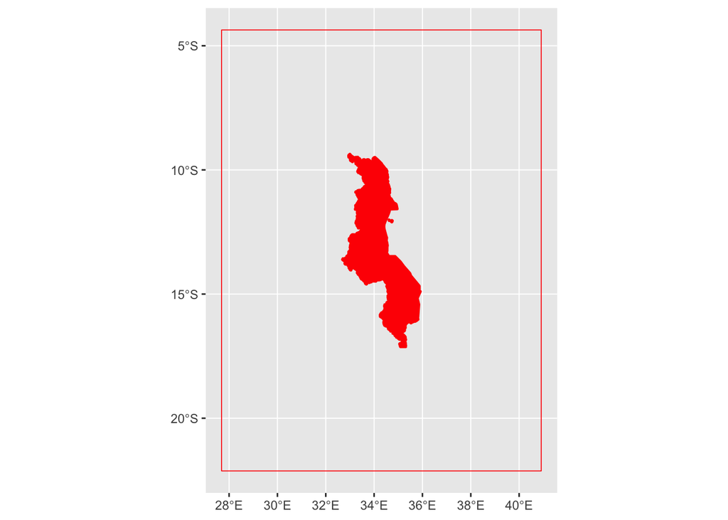

```r
#Creating polygon to indicate zoom
poly <- sp_df %>%
  st_as_sf(coords = c("lon", "lat"),
           crs = st_crs(mwi)) %>%
  st_bbox() %>%
  st_as_sfc()

#Examining what we just created
ggplot() +
  geom_sf(data = mwi, fill="red", color = "red", linewidth = 0.9)+
  geom_sf(data = poly, fill=NA, color = "red", linewidth = 0.3)
```

## 3.4 Cropping the raster

We now crop our raster only to the area of interest. Again, if we have too much, our computer will have a hard time rendering the file.

```r
#Deciding on the error
error3<-3
e <- extent(min_lon_x-error3, max_lon_x+error3, min_lat_y-error3, max_lat_y+error3)
rc <- crop(raster, e)

#Lower resolution raster
rc.aggregate <- aggregate(rc, fact=1)
res(rc.aggregate)

#Get rid of really high mountains
rc <- reclassify(rc.aggregate, c(10000,Inf,NA))
rm(rc.aggregate)
rna <- reclassify(rc, cbind(NA, 0))

rm(rc)
#Convert rasters TO dataframes for plotting with ggplot
hdf <- rasterToPoints(rna); hdf <- data.frame(hdf)
colnames(hdf) <- c("X","Y","Hill")
```

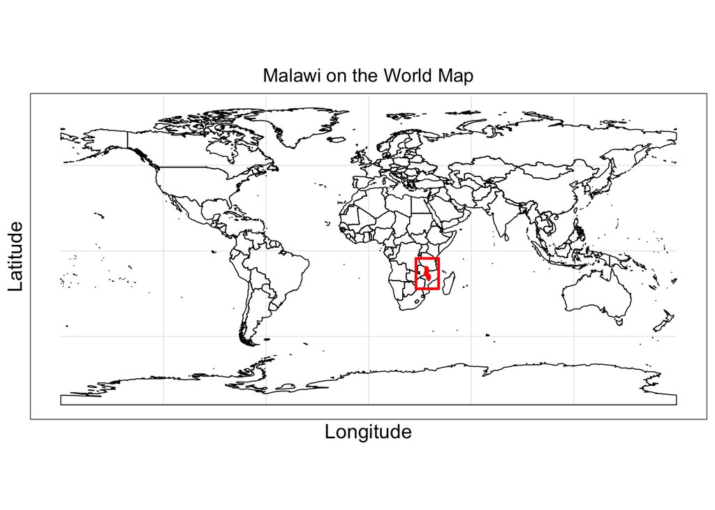

```r
map_word<-ggplot() +
  #geom_raster(data=hdf,aes(X,Y,alpha=Hill)) +
  #scale_alpha(name = "Altitude", guide = "none")  +
  geom_sf(data = world, fill=NA, color = "black", linewidth = 0.3)+
  geom_sf(data = mwi, fill="red", color = "red", linewidth = 0.7)+
  geom_sf(data = poly, fill=NA, color = "red", linewidth = 0.9)+
  theme_bw()+
  labs(x = "Longitude", y="Latitude")+
  ggtitle("Malawi on the World Map")+
    theme(axis.text.x = element_text(size=14),
        axis.text.y = element_text(size=14),
        axis.title=element_text(size=14),
        plot.title = element_text(hjust = 0.5),
        legend.position = c(1, 0),
        #Legend.position values should be between 0 and 1. c(0,0) corresponds to the "bottom left"
        #and c(1,1) corresponds to the "top right" position.
        legend.box.background = element_rect(fill='white'),
        legend.background = element_blank(),
        legend.text=element_text(size=12))
#ggspatial::annotation_scale(location = 'tr')
map_word
```

```r
ggsave(map_word, file="./graphs/map_world.jpg", height=15, width=30, units = "cm", dpi=300)
```

## 3.5 Mapping the region of interest - Malawi

```r
#Calculating polygon centroids
mwi1$lonlat<-st_centroid(st_geometry(mwi1))
mwi1[c('lon_x', 'lat_y')]<-str_split_fixed(mwi1$lonlat, ", ", 2)
mwi1$lat_y<-as.numeric(str_replace(mwi1$lat_y, "\\)", ""))
mwi1$lon_x<-as.numeric(str_replace(mwi1$lon_x, "c\\(", ""))
#Selecting only the region of interest
mwi1_lab<-subset(mwi1, NAME_1=="Nkhata Bay")
```

This is the region of Nkhata Bay where the World Bank ran the RCT. Within the region of Nkhata Bay, the World Bank chose three settlements close to the lake where people could be exposed to malaria.

We now want to draw a new map to emphasize where Nkhata Bay is.

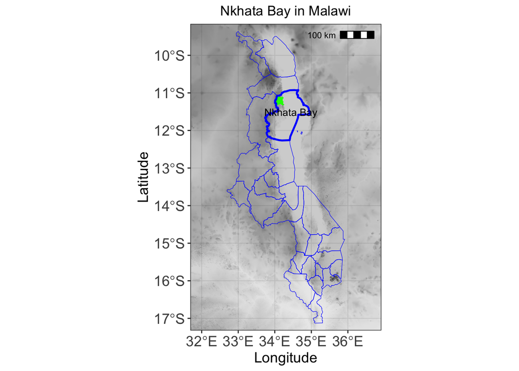

```r
error=0.2
map_malawi<-ggplot() +
  geom_raster(data=hdf,aes(X,Y,alpha=Hill)) +
  scale_alpha(name = "Altitude", guide = "none")  +
  #geom_sf(data = world, fill=NA, color = "black", linewidth = 0.4)+
  #geom_sf(data = mwi, fill=NA, color = "red", linewidth = 0.7)+
  geom_sf(data = select_comm, fill="green", color = "green", linewidth = 0.4)+
  geom_sf(data = mwi1, fill=NA, color = "blue", linewidth = 0.2)+
  #geom_sf(data = mwi3, fill=NA, color = "red", linewidth = 0.4)+
  geom_sf(data = mwi1_lab, fill=NA, color = "blue", linewidth = 0.9)+
  geom_text(data = mwi1_lab, aes(x = lon_x, y = lat_y, label = NAME_1), hjust=0.4, vjust=0, size = 3.5) +
  theme_bw()+
  labs(x = "Longitude", y="Latitude")+
    ggtitle("Nkhata Bay in Malawi")+
    theme(axis.text.x = element_text(size=14),
        axis.text.y = element_text(size=14),
        axis.title=element_text(size=14),
        plot.title = element_text(hjust = 0.5),
        legend.position = c(1, 0),
        #Legend.position values should be between 0 and 1. c(0,0) corresponds to the "bottom left"
        #and c(1,1) corresponds to the "top right" position.
        legend.box.background = element_rect(fill='white'),
        legend.background = element_blank(),
        legend.text=element_text(size=12))+
     coord_sf(xlim = c(min_lon_x-5*error, max_lon_x+5*error), ylim = c(min_lat_y-error, max_lat_y+error), expand = FALSE)+
      ggspatial::annotation_scale(location = 'tr')

map_malawi
```

```r
ggsave(map_malawi, file="./graphs/map_malawi.jpg", height=15, width=15, units = "cm", dpi=300)
```

## 3.6 Calculating the appropriate zoom level for the Selected Communes

We now calculate the zoom level for the region of interest - Nkhata Bay.

```r
nc_geom2 <- st_geometry(select_comm)
#This is because it's a polycon. Note the double brackets from before
list_points_mwi2<-nc_geom2[1]
list_points_mwi2b<-flatten(list_points_mwi2)
list_points_mwi2c<-as.data.frame(do.call(rbind, list_points_mwi2b))
names(list_points_mwi2c)<-c("lon_x", "lat_y")

min_lon_x<-min(list_points_mwi2c$lon_x)
max_lon_x<-max(list_points_mwi2c$lon_x)

min_lat_y<-min(list_points_mwi2c$lat_y)
max_lat_y<-max(list_points_mwi2c$lat_y)
```

```r
#Re-reading the shapefiles.
#We now want more accurate polygons since we are zooming in.
#This is why we load them again

mwi <- st_read("./data/malawi-latest-free/gadm41_MWI_0.shp")
mwi1 <- st_read("./data/malawi-latest-free/gadm41_MWI_1.shp")
mwi3 <- st_read("./data/malawi-latest-free/gadm41_MWI_3.shp")
select_comm <- st_read("./data/malawi-latest-free/selected_communes3.shp")
raster <- raster("./data/elev.tif")

#Also we need a more detailed elevation
error3<-3
e <- extent(min_lon_x-error3, max_lon_x+error3, min_lat_y-error3, max_lat_y+error3)
rc <- crop(raster, e)

#Lower resolution raster
#rc.aggregate <- aggregate(rc, fact=1)
rc.aggregate<-rc
res(rc.aggregate)

#Get rid of really high mountains
rc <- reclassify(rc.aggregate, c(10000,Inf,NA))
rm(rc.aggregate)
rna <- reclassify(rc, cbind(NA, 0))

rm(rc)
#Convert rasters TO dataframes for plotting with ggplot
hdf <- rasterToPoints(rna); hdf <- data.frame(hdf)
colnames(hdf) <- c("X","Y","Hill")

world <- ne_countries(scale = "medium", returnclass = "sf")
#Turning off spherical geometries
sf::sf_use_s2(FALSE)
```

```r
#We also want to include roads in our map, to provide more context.
#Reading the OSM roads data
roads<-st_read("./data/malawi-latest-free/gis_osm_roads_free_1_crop2.shp")
#Step1: Dissolving polylines
roads2 <- st_combine(roads)
#Step2: Turning roads2 into an sf object
roads3<-st_as_sf(roads2)
#Step3: Only the roads of interest
roads_crop1 <- sf::st_intersection(roads3, select_comm)
```

## 3.7 Mapping the Individuals

Let us first look at our data.

```r
rct_data <- read.csv(file = './data/rct_data_geo_malawi.csv')
glimpse(rct_data, n=10)
```

```
Rows: 1,000
Columns: 10
$ id                <int> 1, 2, 3, 4, 5, 6, 7, 8, 9, 10, 11, 12, 13, 14, 15, 1…
$ lat               <dbl> -11.27476, -11.15300, -11.13967, -11.25544, -11.1777…
$ lon               <dbl> 34.03006, 34.14594, 34.14297, 34.14619, 34.20031, 34…
$ income            <dbl> 409.4701, 520.8072, 581.3331, 324.0727, 532.1844, 53…
$ age               <int> 10, 35, 7, 43, 45, 51, 24, 17, 38, 69, 10, 21, 32, 3…
$ sex               <chr> "Man", "Woman", "Woman", "Woman", "Man", "Woman", "M…
$ health            <dbl> 82.78928, 81.18602, 80.57399, 82.84023, 87.40737, 57…
$ net               <int> 0, 1, 0, 0, 1, 1, 1, 0, 1, 1, 1, 1, 1, 1, 0, 0, 0, 1…
$ malaria_risk_pre  <dbl> 35.74454, 36.65260, 22.87415, 35.41934, 27.49873, 42…
$ malaria_risk_post <dbl> 42.52199, 34.27589, 32.67552, 43.87256, 27.16945, 41…
```

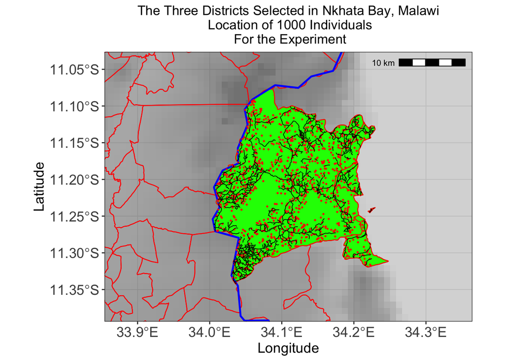

```r
error<-0.05
map_malawi_exp<-ggplot() +
  geom_raster(data=hdf,aes(X,Y,alpha=Hill)) +
  scale_alpha(name = "Altitude", guide = "none")  +
  #geom_sf(data = world, fill=NA, color = "black", linewidth = 0.4)+
  geom_sf(data = select_comm, fill="green", color = "green", linewidth = 0.4)+

  geom_sf(data = mwi1, fill=NA, color = "blue", linewidth = 0.2)+
  geom_sf(data = mwi3, fill=NA, color = "red", linewidth = 0.4)+
  geom_sf(data = mwi1_lab, fill=NA, color = "blue", linewidth = 0.9)+
  geom_point(data = rct_data, aes(x = lon, y= lat), color = "red", size=0.3)+
    geom_sf(data = roads_crop1, fill=NA, color = "black", linewidth = 0.3)+
  theme_bw()+
  labs(x = "Longitude", y="Latitude")+
  ggtitle("The Three Districts Selected in Nkhata Bay, Malawi\n Location of 1000 Individuals\n For the Experiment")+
    theme(axis.text.x = element_text(size=14),
        axis.text.y = element_text(size=14),
        axis.title=element_text(size=14),
        plot.title = element_text(hjust = 0.5),
        legend.position = c(1, 0),
        #Legend.position values should be between 0 and 1. c(0,0) corresponds to the "bottom left"
        #and c(1,1) corresponds to the "top right" position.
        legend.box.background = element_rect(fill='white'),
        legend.background = element_blank(),
        legend.text=element_text(size=12))+
      coord_sf(xlim = c(min_lon_x-3*error, max_lon_x+3*error), ylim = c(min_lat_y-error, max_lat_y+error), expand = FALSE)+
      ggspatial::annotation_scale(location = 'tr')

ggsave(map_malawi_exp, file="./graphs/map_malawi_exp.jpg", height=15, width=15, units = "cm", dpi=300)

map_malawi_exp
```

## 3.8 Mapping the Individuals in an Interactive Way

Here is how we can make an interactive map.

```r
rct_data$treat<-NA
rct_data$treat[rct_data$net==1]<-"Treatment"
rct_data$treat[rct_data$net==0]<-"Control"


#name <- colorFactor(topo.colors(3), domain = carrefour$name)
pal <-
   colorFactor(palette = c("blue", "red"),
               levels = c("Control", "Treatment"))


leaflet(rct_data) %>% addTiles() %>%
addPolygons(data = select_comm,
                group = "Nkhata Bay",
    # stroke parameters
    weight = 3, color = "blue",
    # fill parameters
    fillColor = "blue", fillOpacity = 0.0)%>%

  addCircleMarkers(lng = ~lon, lat = ~lat,
             label = ~htmlEscape(paste("Indiv.: ", id)), radius = 4, color = ~pal(treat))%>%
  addLegendFactor(
    pal=pal,
    values = rct_data$treat,
    position = 'topright',
    shape = 'circle',
    width = 10,
    height = 10,
    opacity = .5)%>%
  addScaleBar(
  position = c("bottomright"))
```

[interactive chart not shown]

# 4 Data Analysis

We will now do the data analysis. Until now, we looked at various ways of mapping our data.

## 4.1 Summary statisics

Before we conduct any analysis, it is important to get a sense of our data, the minimum and maximum, the mean, and whether our variables are normally distributed or not. Let us now create a summary statistics table:

```r
datasummary_skim(rct_data)
```

Unique (#)

Missing (%)

Mean

SD

Min

Median

Max

id

1000

0

500.5

288.8

1.0

500.5

1000.0

lat

1000

0

−11.2

0.1

−11.3

−11.2

−11.1

[figure not shown]

lon

1000

0

34.1

0.1

34.0

34.1

34.2

income

1000

0

498.0

74.8

245.3

497.0

739.7

age

76

0

28.9

16.1

1.0

27.0

89.0

health

1000

0

69.1

12.9

30.9

69.0

100.0

[figure not shown]

net

2

0

0.5

0.5

0.0

1.0

1.0

malaria_risk_pre

1000

0

38.0

9.8

5.0

37.9

70.0

malaria_risk_post

1000

0

40.4

10.4

5.0

40.5

70.0

## 4.2 Checking balance

Before calculating the effect of the program, we should first check how well balanced assignment was. As you can tell from the results below, assignment to the program was pretty much split 50/50.

```r
people_randomized<-rct_data %>%
  count(net) %>%
  mutate(prop = n / sum(n))
people_randomized
```

| net | n | prop |
| --- | --- | --- |
| 0 | 478 | 0.478 |
| 1 | 522 | 0.522 |

We also want to check to see how well balanced the treatment and control groups were in participants’ pre-treatment characteristics:

```r
rct_data$sex_num<-as.numeric(as.factor(as.character(rct_data$sex)))
rct_data$sex_num[rct_data$sex_num==2]<-0

people_randomized<-rct_data %>%
  group_by(net) %>%
  summarize(prop_male = mean(sex_num),
    avg_age = mean(age),
    avg_malaria_risk_pre = mean(malaria_risk_pre),
    avg_health = mean(health),
    avg_income = mean(income))

people_randomized
```

| net | prop_male | avg_age | avg_malaria_risk_pre | avg_health | avg_income |
| --- | --- | --- | --- | --- | --- |
| 0 | 0.3933054 | 28.25523 | 37.96975 | 68.90312 | 498.4966 |
| 1 | 0.3984674 | 29.54981 | 37.95993 | 69.23106 | 497.5552 |

These variables appear fairly well balanced. To check that there aren’t any statistically significant differences between the groups, we should also conduct some t-tests.

```r
t.test(sex_num ~ net, data = rct_data, alternative=c("two.sided"))
```

```
    Welch Two Sample t-test

data:  sex_num by net
t = -0.16658, df = 990.67, p-value = 0.8677
alternative hypothesis: true difference in means between group 0 and group 1 is not equal to 0
95 percent confidence interval:
 -0.06597315  0.05564916
sample estimates:
mean in group 0 mean in group 1
      0.3933054       0.3984674
```

```r
t.test(age ~ net, data = rct_data, alternative=c("two.sided"))
```

```
    Welch Two Sample t-test

data:  age by net
t = -1.275, df = 997.37, p-value = 0.2026
alternative hypothesis: true difference in means between group 0 and group 1 is not equal to 0
95 percent confidence interval:
 -3.2870789  0.6979223
sample estimates:
mean in group 0 mean in group 1
       28.25523        29.54981
```

```r
t.test(malaria_risk_pre ~ net, data = rct_data, alternative=c("two.sided"))
```

```
    Welch Two Sample t-test

data:  malaria_risk_pre by net
t = 0.015818, df = 997.7, p-value = 0.9874
alternative hypothesis: true difference in means between group 0 and group 1 is not equal to 0
95 percent confidence interval:
 -1.208182  1.227819
sample estimates:
mean in group 0 mean in group 1
       37.96975        37.95993
```

```r
t.test(health ~ net, data = rct_data, alternative=c("two.sided"))
```

```
    Welch Two Sample t-test

data:  health by net
t = -0.40132, df = 996.97, p-value = 0.6883
alternative hypothesis: true difference in means between group 0 and group 1 is not equal to 0
95 percent confidence interval:
 -1.931451  1.275577
sample estimates:
mean in group 0 mean in group 1
       68.90312        69.23106
```

```r
t.test(income ~ net, data = rct_data, alternative=c("two.sided"))
```

```
    Welch Two Sample t-test

data:  income by net
t = 0.19875, df = 991.26, p-value = 0.8425
alternative hypothesis: true difference in means between group 0 and group 1 is not equal to 0
95 percent confidence interval:
 -8.353269 10.236022
sample estimates:
mean in group 0 mean in group 1
       498.4966        497.5552
```

We can also simply ask to be shown the p-values.

```r
t.test(sex_num ~ net, data = rct_data, alternative=c("two.sided"))[3]
```

```
$p.value
[1] 0.8677374
```

```r
t.test(age ~ net, data = rct_data, alternative=c("two.sided"))[3]
```

```
$p.value
[1] 0.2026112
```

```r
t.test(malaria_risk_pre ~ net, data = rct_data, alternative=c("two.sided"))[3]
```

```
$p.value
[1] 0.9873827
```

```r
t.test(health ~ net, data = rct_data, alternative=c("two.sided"))[3]
```

```
$p.value
[1] 0.6882691
```

```r
t.test(income ~ net, data = rct_data, alternative=c("two.sided"))[3]
```

```
$p.value
[1] 0.8424983
```

## 4.3 Plotting Differences

The following graphs plot the point ranges for the variables of interest.

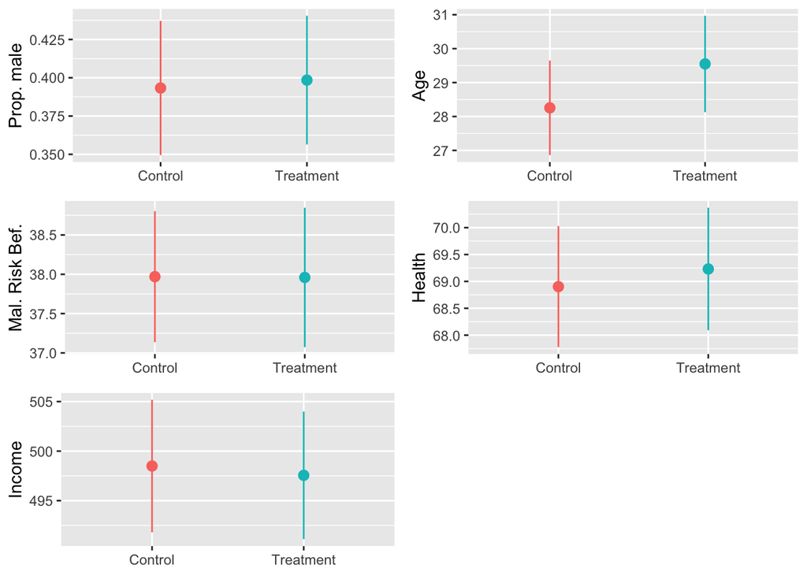

```r
#The value of 1.96 is based on the fact that 95% of the area of a normal distribution is within 1.96 standard deviations of the mean

plot_diff_sex <- ggplot(rct_data, aes(x = treat, y = sex_num, color = treat)) +
  stat_summary(geom = "pointrange", fun.data = "mean_se", fun.args = list(mult = 1.96)) +
  guides(color = "none") +
  labs(x = NULL, y = "Prop. male")

plot_diff_age <- ggplot(rct_data, aes(x = treat, y = age, color = treat)) +
  stat_summary(geom = "pointrange", fun.data = "mean_se", fun.args = list(mult = 1.96)) +
  guides(color = "none") +
  labs(x = NULL, y = "Age")

plot_diff_malaria_risk_pre <- ggplot(rct_data, aes(x = treat, y = malaria_risk_pre, color = treat)) +
  stat_summary(geom = "pointrange", fun.data = "mean_se", fun.args = list(mult = 1.96)) +
  guides(color = "none") +
  labs(x = NULL, y = "Mal. Risk Bef.")


plot_diff_health <- ggplot(rct_data, aes(x = treat, y = health, color = treat)) +
  stat_summary(geom = "pointrange", fun.data = "mean_se", fun.args = list(mult = 1.96)) +
  guides(color = "none") +
  labs(x = NULL, y = "Health")

plot_diff_income <- ggplot(rct_data, aes(x = treat, y = income, color = treat)) +
  stat_summary(geom = "pointrange", fun.data = "mean_se", fun.args = list(mult = 1.96)) +
  guides(color = "none") +
  labs(x = NULL, y = "Income")

ggarrange(plot_diff_sex, plot_diff_age,
             plot_diff_malaria_risk_pre,
             plot_diff_health, plot_diff_income, ncol=2, nrow=3, common.legend = TRUE)
```

Let us now also include the distributions of these variables by group (treatment and control group).

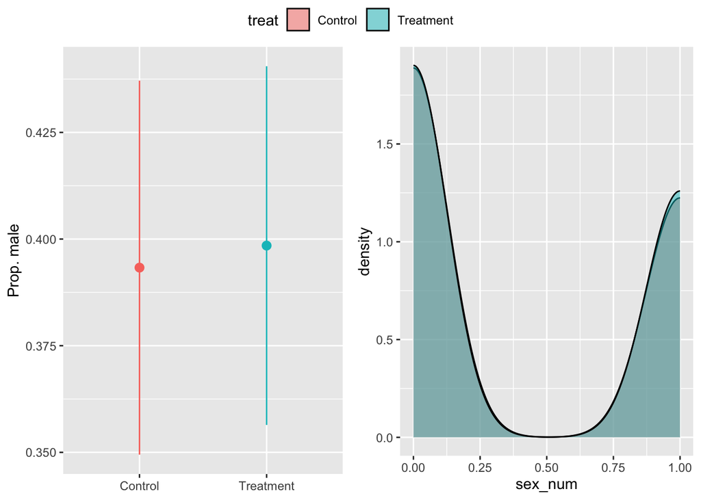

```r
plot_diff_sex_d<-ggplot(rct_data, aes(x = sex_num, fill = treat, group=treat)) +
  guides(color = "none") +
  geom_density(alpha = 0.5)

plot_diff_age_d<-ggplot(rct_data, aes(x = age, fill = treat, group=treat)) +
  guides(color = "none") +
  geom_density(alpha = 0.5)

plot_diff_malaria_risk_pre_d<-ggplot(rct_data, aes(x = malaria_risk_pre, fill = treat, group=treat)) +
  guides(color = "none") +
  geom_density(alpha = 0.5)

plot_diff_health_d<-ggplot(rct_data, aes(x = health, fill = treat, group=treat)) +
  guides(color = "none") +
  geom_density(alpha = 0.5)

plot_diff_income_d<-ggplot(rct_data, aes(x = income, fill = treat, group=treat)) +
  guides(color = "none") +
  geom_density(alpha = 0.5)

ggarrange(plot_diff_sex, plot_diff_sex_d, ncol=2, common.legend = TRUE)
```

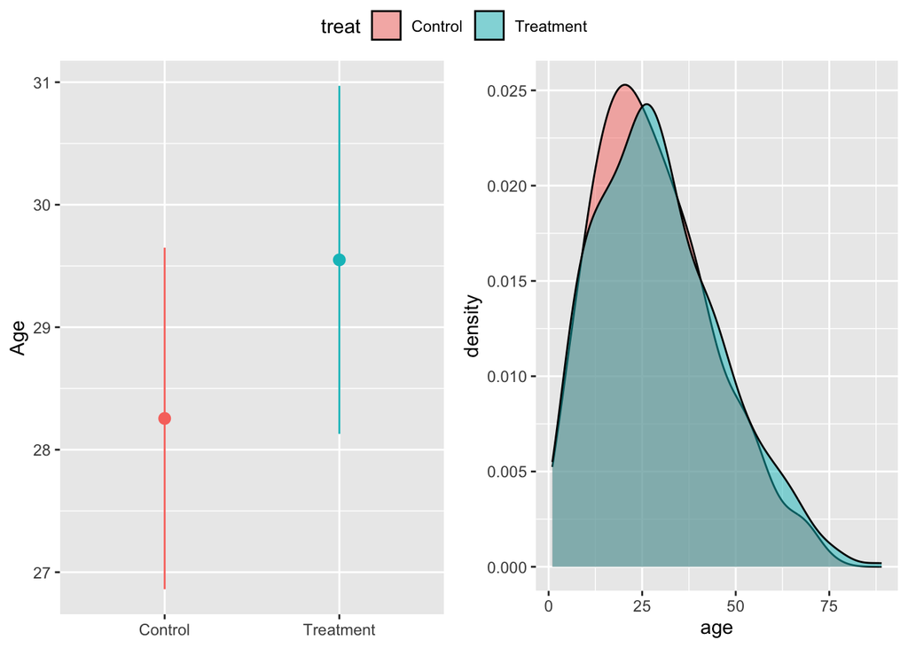

```r
ggarrange(plot_diff_age, plot_diff_age_d, ncol=2, common.legend = TRUE)
```

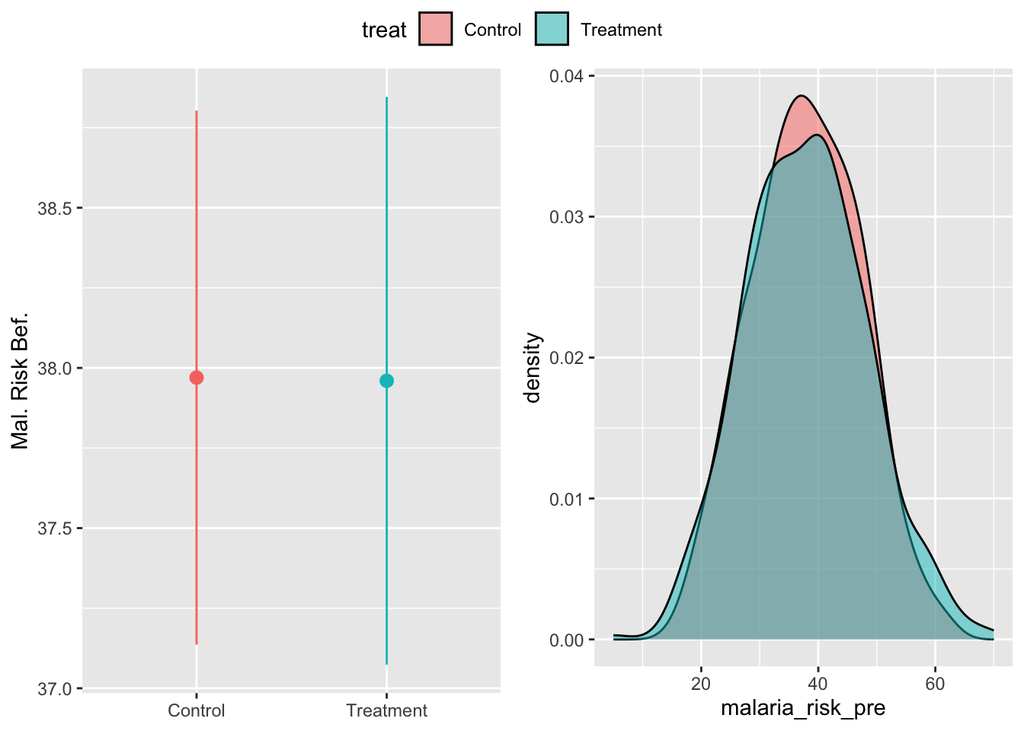

```r
ggarrange(plot_diff_malaria_risk_pre, plot_diff_malaria_risk_pre_d, ncol=2, common.legend = TRUE)
```

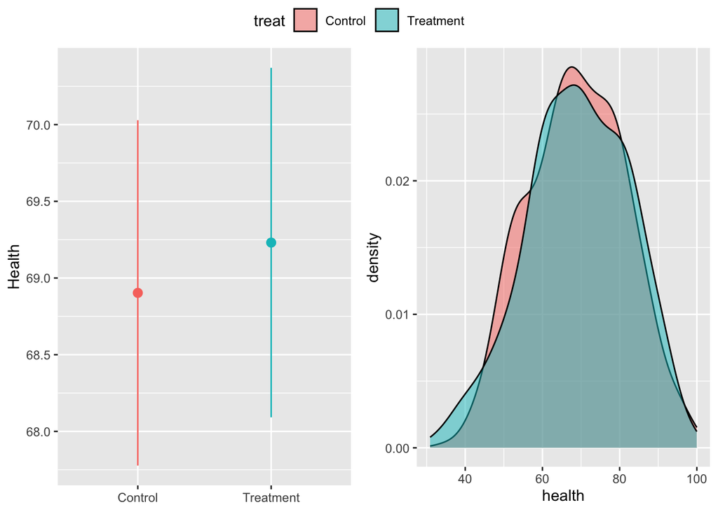

```r
ggarrange(plot_diff_health, plot_diff_health_d, ncol=2, common.legend = TRUE)
```

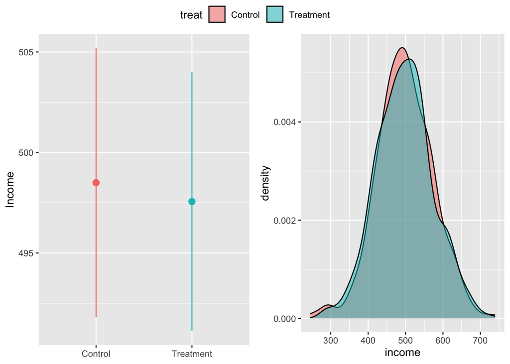

```r
ggarrange(plot_diff_income, plot_diff_income_d, ncol=2, common.legend = TRUE)
```

## 4.4 Estimating the Difference

So, we are interested in the causal effect of the program - $E(\text{Post-Malaria Risk | Net})$. We can find this causal effect by calculating the average treatment effect or ATE:

$$ATE = E(\overline{\text{Post-Malaria Risk}} | \text{Net = 1}) - E(\overline{\text{Post-Malaria Risk}} | \text{Net = 0})$$

This is simply the average outcome for people in the program minus the average outcome for people not in the program. We can calculate the group averages:

```r
people_randomized<-rct_data %>%
  group_by(net) %>%
  summarize(avg_malaria_risk_post = mean(malaria_risk_post))

people_randomized
```

| net | avg_malaria_risk_post |
| --- | --- |
| 0 | 45.66210 |
| 1 | 35.57936 |

That’s 45.66210 -35.57936, or 10.08274, which means that the program caused an decrease in the risk of malaria of 10.08274, on average. We can also simply run a regression with post-program malaria risk as the outcome variable and the program indicator variable as the explanatory variable. The results below show two models: (1) in which we simply control for the treatment status and one in which we add a series of controls. We can see that we get the same effect of 10.08274, which we calculated manually. This is very close in magnitude to 10.235, which is the effect, once we control for income, age, and sex.

```r
model_rct1 <- lm(malaria_risk_post ~ net, data = rct_data)
summary(model_rct1)
```

```
Call:
lm(formula = malaria_risk_post ~ net, data = rct_data)

Residuals:
     Min       1Q   Median       3Q      Max
-30.5794  -6.4719   0.0798   6.1909  28.9747

Coefficients:
            Estimate Std. Error t value Pr(>|t|)
(Intercept)  45.6621     0.4146  110.14   <2e-16 ***
net         -10.0827     0.5738  -17.57   <2e-16 ***
---
Signif. codes:  0 '***' 0.001 '**' 0.01 '*' 0.05 '.' 0.1 ' ' 1

Residual standard error: 9.064 on 998 degrees of freedom
Multiple R-squared:  0.2363,    Adjusted R-squared:  0.2355
F-statistic: 308.7 on 1 and 998 DF,  p-value: < 2.2e-16
```

```r
model_rct1 <- lm(malaria_risk_post ~ net, data = rct_data)
model_rct2 <- lm(malaria_risk_post ~ net + income + age + sex_num, data = rct_data)


models<-list("Risk of Malaria" = model_rct1,
             "Risk of Malaria" = model_rct2)

cm <- c('net'='Received Mosquito Net (Treatment)',
        "income" = "income",
        "age" = "age",
        "sex_num" = "sex",
        "(Intercept)"="Intercept")

modelsummary(models, stars = TRUE, coef_map = cm, gof_map = c("nobs", "r.squared"))
```

|  | Risk of Malaria | Risk of Malaria |
| --- | --- | --- |
| Received Mosquito Net (Treatment) | −10.083*** | −10.235*** |
|  | (0.574) | (0.527) |
| income |  | −0.045*** |
|  |  | (0.004) |
| age |  | 0.083*** |
|  |  | (0.016) |
| sex |  | 0.518 |
|  |  | (0.539) |
| Intercept | 45.662*** | 65.608*** |
|  | (0.415) | (1.866) |
| Num.Obs. | 1000 | 1000 |
| R2 | 0.236 | 0.359 |

+ p < 0.1, * p < 0.05, ** p < 0.01, *** p < 0.001

Let us now also plot this difference.

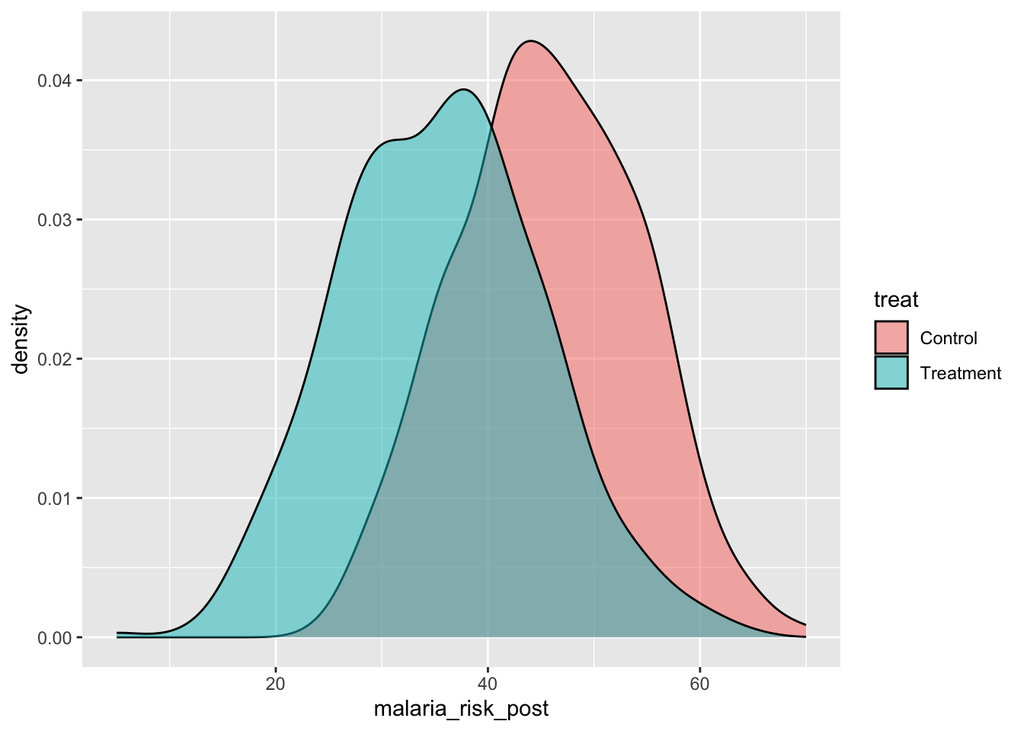

```r
ggplot(rct_data, aes(x = malaria_risk_post, fill = treat, group=treat)) +
  geom_density(alpha = 0.5)
```

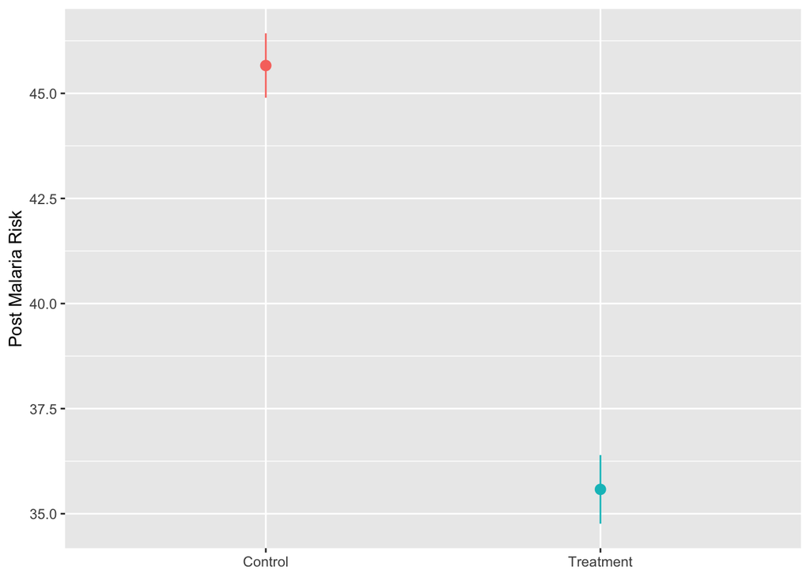

```r
ggplot(rct_data, aes(x = treat, y = malaria_risk_post, color = treat)) +
  stat_summary(geom = "pointrange", fun.data = "mean_se", fun.args = list(mult = 1.96)) +
  guides(color = "none") +
  labs(x = NULL, y = "Post Malaria Risk")
```

# 5 Conclusion

We can now conclude that indeed the provision of insecticide-treated nets reduces the risk of malaria by 10.083 units. Thus, if the we want to reduce such a health risk to the wider region, it might be effective to provide such nets to all vulnerable populations.

Let us recap the steps in the analysis of RCTs

- Step 1: Check balance
- Step 2: Calculate the difference
- Step 3: Show the difference